# Worlds End Traverse Analysis

Tomas Castillo

June 30, 2016

## Exploring Personal Data

Last weekend, I took a trip out to Worlds End State Park in the Northeast part of Pennyslvania. It’s nestled in the heart of the Endless Mountains and the Loyalsock State Forest. The route that I picked was not my own choosing, but is in fact a race course for the Worlds End 100k.

I was treating this run as a training experience and a way to explore some of the beautiful and wild parts of the state. And that it was.

I was exploring some other blogs on racing and came across someone who did an analysis on their own training efforts that compared their average paces in each category of grades. I hadn’t thought of looking at this approach and decided to pull out my effort at Worlds End to see how my climbing pace looks at different grades.

I tracked the Traverse with a Suunto Ambit3 Peak, and then pulled the data out from Movescount.

This way, the data looks similar to what would show up on Movescount, Strava, TrainingPeaks, MapMyRun, or whatever else might display the GPS data.

If we can explore this to see what we’ve got, we’ll first just do an overview of what the climbing profile looks like.

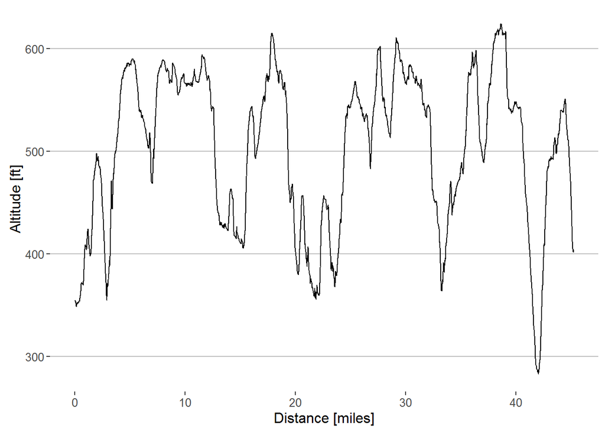

Some nice climbs and descents, and all of it was technical! Ha… good stuff. I should point out that the race is a 100k category and comes out to 63 miles. I’ve got a few excuses for not finishing the full 63 miles, but a majority of the reason was my knees had taken a beating through all the technicality, the heat had taken its toll on my overall strength, and it was getting late and I didn’t want to run in the dark since I was alone (I do, in fact, get scared). My total mileage came out to 45 miles. Not bad if you ask me, especially considering the longest I had run before was 36 miles.

Now that we’ve got that explanation out of the way, let’s look a the paces and how the grade of elevation affects it.

First, we’ll just look at the grade of the course.

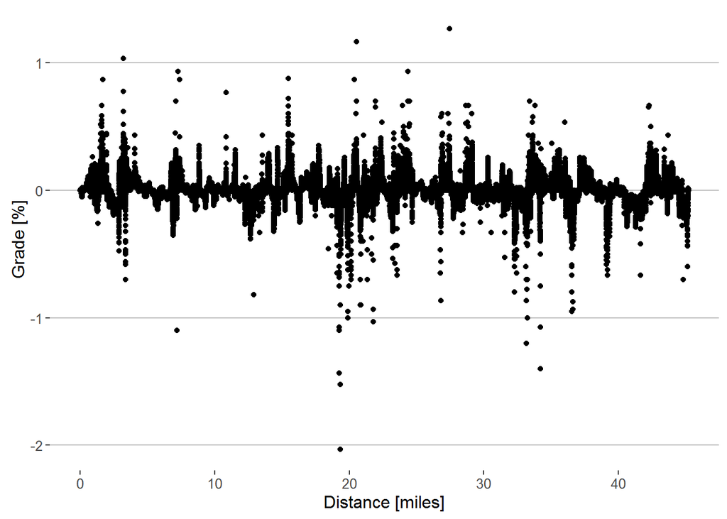

Something to notice about the data and then to think about in terms of what it means. There are some points over 100%, and even some descents over -200%. Recall that grade is vertical gain/horizontal distance, as a percent (so 1% = 1 ft up for 100 ft horizontal).

Then, if we apply some old fashioned trigonometry, we can figure out the angle. The max grade was 1.27% giving it an angle (in degrees) of 51.7. That’s pretty steep, but actually not unreasonable - it’s just really steep.

The negative grade of 200% gives us a descent angle of 64. In thinking back, I can probably guess at which point that was because I was going on very slowly and trying to jump from rock to rock as I was descending.

Alright, so we’ll set up some bins that will categorize the grade. The reasoning behind the categories below are what goes from extremely steep, towards a more runnable grade, to flat. Ideally, the grade would be stepped in 2.5% increments, but because of the large range, we’ll lump some of the more extreme grades together.

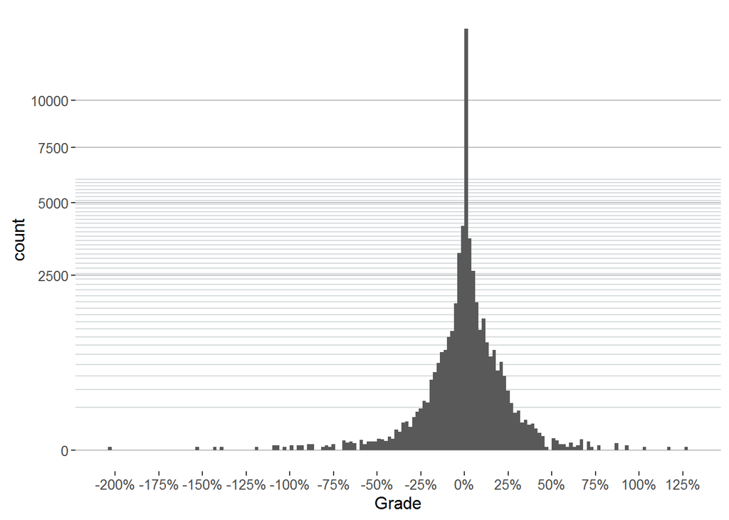

```r
ggplot(we.traverse, aes(Grade)) +
  geom_histogram(binwidth = 0.02) +
  coord_trans(y = 'sqrt') +
  scale_y_continuous(minor_breaks = seq(0, 6000, 150),
                     breaks = seq(0, 10000, 2500)) +
  scale_x_continuous(breaks = seq(-2, 150, 0.25),
                     labels = paste0(seq(-2, 150, 0.25)*100, "%")) +
  theme_hc() +
  theme(panel.grid.minor.y = element_line(color = "#d5dbdd", size = 0.5))
```

As one would expect, most of the grades are actually reasonable and below 50% (both positive and negative). We’ll add the bins and then plot accordingly.

```r
# Not too many steep grades
gradeBin <- c(-2.5, -1, -0.6, -0.3, -0.25, -0.20, -0.15, -0.125, -0.10, -0.075, -0.05, -0.025, 0,
              0.025, 0.05, 0.075, 0.10, 0.125, 0.15, 0.20, 0.25, 0.3, 0.6, 1, 2.5)
```

As I was going through this, I realized that we should take out any points that have a speed of 0. The reason for that is it’s just time that I was still at an aid station (my girlfriend’s car), resting, or I was navigating trying to find my way back on the trail. Since my watch also records `Cadence`, we can take out any points I was standing still with a `Cadence` of 0 as well.

Because we’re only interested in the metrics related to moving, we can subset the data.

```r
we.traverse <- subset(we.traverse, Speed > 0 & Cadence > 0)
```

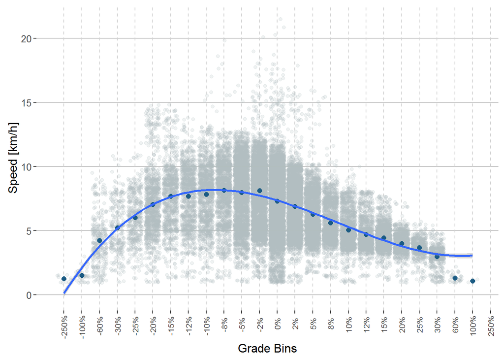

```r
ggplot(we.traverse, aes(x = gradeRank, y = speed.km)) +
  geom_point(position = position_jitter(width = 1), alpha = 0.2, col = '#b0bcbf') +
  geom_point(stat = 'summary', fun.y = mean, col = '#1b5b83', size =2) +
  scale_x_continuous("Grade Bins",
                     breaks = seq(1, 25,1),
                     labels = paste0(format(gradeBin*100, digits = 0),"%")) +
  scale_y_continuous("Speed [km/h]") +
  theme_hc() +
  geom_smooth(method = 'lm', formula = y ~ x*I(x^2)) +
  theme(axis.text.x = element_text(size = 8,
                                   angle = 90, vjust = 0.5),
        panel.grid.major.x = element_line(color = "light grey",
                                          linetype = 2))
```

While this fit seems to work, I don’t usually look at my speed, but rather at my pace. So let’s convert `Speed` to `pace`. I’ve got it in *km/h* so we’ll need to do a few mathematical transformations first.

```r
we.traverse <- we.traverse %>%
  mutate(pace = (speed.km*(0.621/60))^(-1))
```

We’ll do the same plot as above, but this time, with pace on the y-axis instead of speed.

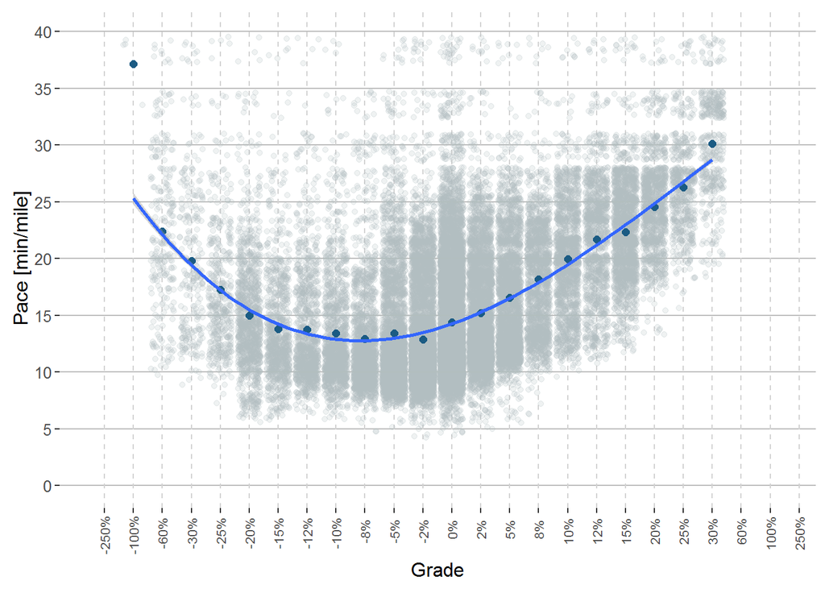

```r
ggplot(we.traverse, aes(x = gradeRank, y = pace)) +
  geom_point(position = position_jitter(width = 1, height = 3), alpha = 0.2, col = '#b0bcbf') +
  geom_point(stat = 'summary', fun.y = mean, col = '#1b5b83', size =2) +
  scale_x_continuous("Grade",
                     breaks = seq(1, 25,1),
                   labels = paste0(format(gradeBin*100, digits = 0),"%")) +
  scale_y_continuous("Pace [min/mile]", breaks = seq(0,75,5),
                     labels = seq(0,75,5), limits = c(0,40)) +
  theme_hc() +
  geom_smooth(method = 'lm', formula = y ~ x*I(x^2)) +
  theme(axis.text.x = element_text(size = 8,
                                   angle = 90, vjust = 0.5),
        panel.grid.major.x = element_line(color = "light grey",
                                          linetype = 2))
```

Good stuff.

So what does a linear model look like for pace over grade? What if we throw in some of the other variables?

Let’s start with just `pace ~ grade rank`.

```r
pg <- lm(pace ~ gradeRank, data = we.traverse)
summary(pg)
```

```
##
## Call:
## lm(formula = pace ~ gradeRank, data = we.traverse)
##
## Residuals:
##     Min      1Q  Median      3Q     Max
## -12.611  -5.329  -2.078   2.898  80.542
##
## Coefficients:
##             Estimate Std. Error t value Pr(>|t|)
## (Intercept)  8.25721    0.17082   48.34   <2e-16 ***
## gradeRank    0.66219    0.01256   52.74   <2e-16 ***
## ---
## Signif. codes:  0 '***' 0.001 '**' 0.01 '*' 0.05 '.' 0.1 ' ' 1
##
## Residual standard error: 9.122 on 38588 degrees of freedom
## Multiple R-squared:  0.06723,    Adjusted R-squared:  0.0672
## F-statistic:  2781 on 1 and 38588 DF,  p-value: < 2.2e-16
```

Great! While it shows that `gradeRank` or `Grade` are both highly correlated… that’s because it’s the only variable. We can do better. The low $R^2$ value doesn’t really do much either. So let’s look at a few more variables.

Let’s back up real quick and evaluate the difference between `pace` and `speed`.

While it’s helpful to think in terms of pace when running, because of the math involved to transform one metric to another, `pace` has much greater variance depending on how fast/slow I’m going.

Recall:
$$pace = (speed[\frac{km}{hr}] * \frac{0.621 miles}{1 km} * \frac{1 hour}{60 min})^{-1}$$

If we look at both of those metrics compared side by side, Speed scales much better for lower and faster speeds. We’ll stick with using speed instead of pace, and we can transform the variable later when necessary.

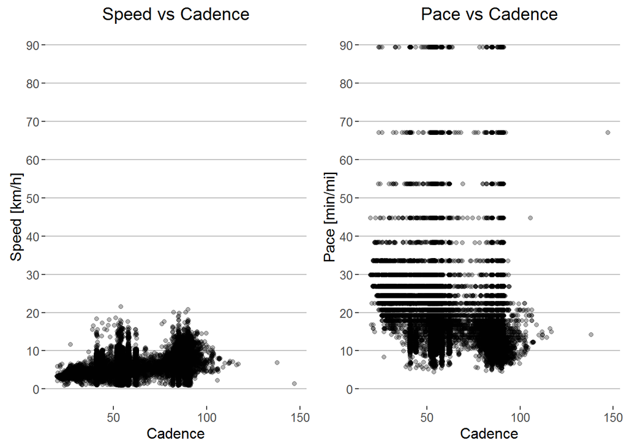

In going over these data, I began to think of other ways to categorize things and thought of one that may be helpful, especially in terms of ultras – whether I’m walking or running. An easy way to pull that out would be to look at the cadence. While this isn’t always the case, a good indicator of whether I’m running vs walking/hiking is a threshold value in cadence.

Obviously this will vary depending on the person, so I’ll have a look at what my values look like.

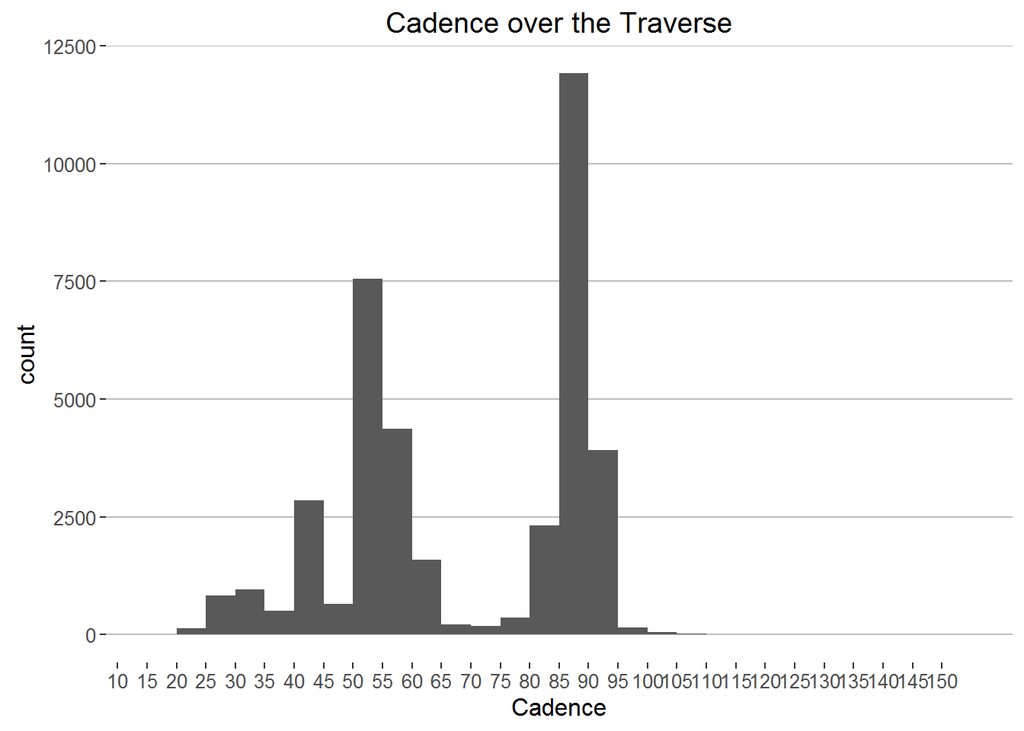

We can now add a cateogry to our data that tells us whether we are walking or not and then see if that makes sense in terms of speed.

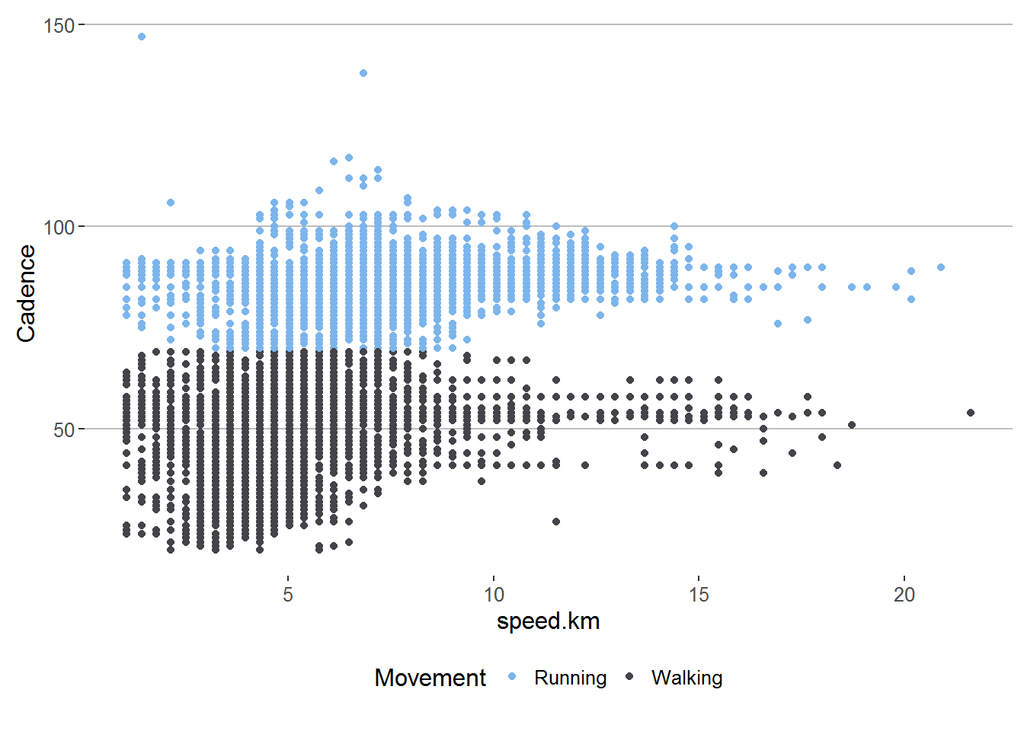

```r
ggplot(we.traverse, aes(x = speed.km, y = Cadence, col = factor(MovementType))) +
  geom_point() +
  theme_hc() +
  scale_color_hc(name = "Movement",
                 breaks = c(0, 1),
                 labels = c("Running", "Walking"))
```

Hmm, something seems off. Maybe it’s not as simple as I thought. Even when my cadence was in the “walking” region, my speed seemed to still indicate I was at running speed. Perhaps, on the downhills, I was taking longer strides?

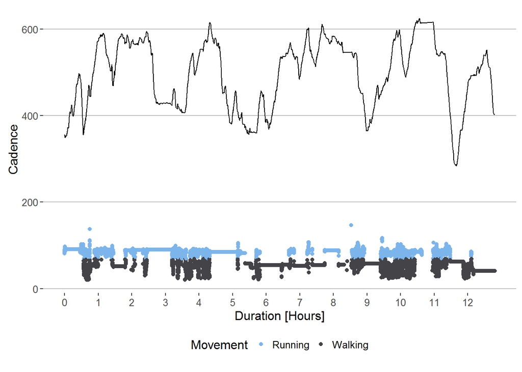

```r
ggplot(we.traverse, aes(x = Duration/3600, y = Cadence)) +
  geom_point(aes(col = factor(MovementType))) +
  theme_hc() +
  scale_color_hc(name = "Movement",
                 breaks = c(0, 1),
                 labels = c("Running", "Walking")) +
  scale_x_continuous("Duration [Hours]",
                     breaks = seq(0, 12, 1),
                     labels = seq(0, 12, 1)) +
  geom_line(aes(y = Altitude))
```

All I’m gathering from this is there is no easy distinction to determine whether I’m walking or not. Because of that, we will remove the categorical variable for `MovementType`. It might be easier to extract than I realize, but for now we’ll remove that category and can explore it later.

## Developing a Model

Now let’s look at a few of the correlations between the metrics recorded.

```
##
## Call:
## lm(formula = speed.km ~ Cadence, data = we.traverse)
##
## Residuals:
##      Min       1Q   Median       3Q      Max
## -10.2708  -1.3130  -0.0945   1.3731  15.6831
##
## Coefficients:
##              Estimate Std. Error t value Pr(>|t|)
## (Intercept) 2.5526121  0.0394785   64.66   <2e-16 ***
## Cadence     0.0623007  0.0005568  111.89   <2e-16 ***
## ---
## Signif. codes:  0 '***' 0.001 '**' 0.01 '*' 0.05 '.' 0.1 ' ' 1
##
## Residual standard error: 2.152 on 38588 degrees of freedom
## Multiple R-squared:  0.245,  Adjusted R-squared:  0.2449
## F-statistic: 1.252e+04 on 1 and 38588 DF,  p-value: < 2.2e-16
```

```
##
## Call:
## lm(formula = speed.km ~ Cadence + Altitude, data = we.traverse)
##
## Residuals:
##      Min       1Q   Median       3Q      Max
## -10.3242  -1.3247  -0.1103   1.3837  15.8166
##
## Coefficients:
##              Estimate Std. Error t value Pr(>|t|)
## (Intercept) 1.0867211  0.0781297   13.91   <2e-16 ***
## Cadence     0.0610587  0.0005564  109.74   <2e-16 ***
## Altitude    0.0031170  0.0001437   21.70   <2e-16 ***
## ---
## Signif. codes:  0 '***' 0.001 '**' 0.01 '*' 0.05 '.' 0.1 ' ' 1
##
## Residual standard error: 2.139 on 38587 degrees of freedom
## Multiple R-squared:  0.2541, Adjusted R-squared:  0.254
## F-statistic:  6571 on 2 and 38587 DF,  p-value: < 2.2e-16
```

```
##
## Call:
## lm(formula = speed.km ~ Cadence + Altitude + HeartRate, data = we.traverse)
##
## Residuals:
##     Min      1Q  Median      3Q     Max
## -8.9682 -1.2729 -0.0962  1.3101 15.9319
##
## Coefficients:
##               Estimate Std. Error t value Pr(>|t|)
## (Intercept) -2.6926923  0.1265887  -21.27   <2e-16 ***
## Cadence      0.0591615  0.0005488  107.79   <2e-16 ***
## Altitude     0.0024948  0.0001421   17.56   <2e-16 ***
## HeartRate    0.0304200  0.0008103   37.54   <2e-16 ***
## ---
## Signif. codes:  0 '***' 0.001 '**' 0.01 '*' 0.05 '.' 0.1 ' ' 1
##
## Residual standard error: 2.101 on 38586 degrees of freedom
## Multiple R-squared:  0.2803, Adjusted R-squared:  0.2803
## F-statistic:  5011 on 3 and 38586 DF,  p-value: < 2.2e-16
```

```
##
## Call:
## lm(formula = speed.km ~ Cadence + Grade + HeartRate, data = we.traverse)
##
## Residuals:
##      Min       1Q   Median       3Q      Max
## -20.7523  -1.1199  -0.0579   1.1559  15.6935
##
## Coefficients:
##               Estimate Std. Error t value Pr(>|t|)
## (Intercept) -3.9802804  0.1140325  -34.91   <2e-16 ***
## Cadence      0.0473286  0.0005546   85.34   <2e-16 ***
## Grade       -6.7313029  0.1018981  -66.06   <2e-16 ***
## HeartRate    0.0551202  0.0008415   65.50   <2e-16 ***
## ---
## Signif. codes:  0 '***' 0.001 '**' 0.01 '*' 0.05 '.' 0.1 ' ' 1
##
## Residual standard error: 2 on 38586 degrees of freedom
## Multiple R-squared:  0.3483, Adjusted R-squared:  0.3482
## F-statistic:  6874 on 3 and 38586 DF,  p-value: < 2.2e-16
```

```
##
## Call:
## lm(formula = speed.km ~ Cadence + Altitude + HeartRate + Grade,
##     data = we.traverse)
##
## Residuals:
##     Min      1Q  Median      3Q     Max
## -20.552  -1.120  -0.064   1.123  15.777
##
## Coefficients:
##               Estimate Std. Error t value Pr(>|t|)
## (Intercept) -4.7414116  0.1241169  -38.20   <2e-16 ***
## Cadence      0.0467469  0.0005542   84.35   <2e-16 ***
## Altitude     0.0020629  0.0001350   15.29   <2e-16 ***
## HeartRate    0.0534874  0.0008458   63.24   <2e-16 ***
## Grade       -6.6552571  0.1017140  -65.43   <2e-16 ***
## ---
## Signif. codes:  0 '***' 0.001 '**' 0.01 '*' 0.05 '.' 0.1 ' ' 1
##
## Residual standard error: 1.994 on 38585 degrees of freedom
## Multiple R-squared:  0.3522, Adjusted R-squared:  0.3522
## F-statistic:  5245 on 4 and 38585 DF,  p-value: < 2.2e-16
```

It may take a little to look through the different models, but we’re just comparing the different variables and they’re output effect.

Something else that may be quite helpful is the duration to which the event has taken. For example, look at the `gradeRank vs Pace` graph, and around the 0% - 2.5% grade region, there are some high points, but also some low points that are in the ‘walking’ range (lower).

2.5% is a pretty mild grade. However, depending on the time of day and how my legs were feeling, I may have decided to walk even a small hill instead. It may not always be an influencing factor, but I think it may shed some additional light on the entire picture.

Let’s add duration to our model.

```
##
## Call:
## lm(formula = speed.km ~ Cadence + Altitude + HeartRate + Grade +
##     Duration, data = we.traverse)
##
## Residuals:
##      Min       1Q   Median       3Q      Max
## -20.5262  -1.1108  -0.0222   1.1464  15.3047
##
## Coefficients:
##               Estimate Std. Error t value Pr(>|t|)
## (Intercept) -2.989e+00  1.502e-01  -19.91   <2e-16 ***
## Cadence      4.226e-02  5.931e-04   71.25   <2e-16 ***
## Altitude     2.368e-03  1.351e-04   17.54   <2e-16 ***
## HeartRate    4.505e-02  9.365e-04   48.10   <2e-16 ***
## Grade       -6.661e+00  1.012e-01  -65.84   <2e-16 ***
## Duration    -1.879e-05  9.163e-07  -20.50   <2e-16 ***
## ---
## Signif. codes:  0 '***' 0.001 '**' 0.01 '*' 0.05 '.' 0.1 ' ' 1
##
## Residual standard error: 1.983 on 38584 degrees of freedom
## Multiple R-squared:  0.3592, Adjusted R-squared:  0.3591
## F-statistic:  4326 on 5 and 38584 DF,  p-value: < 2.2e-16
```

```
##
## Call:
## lm(formula = speed.km ~ Cadence + Altitude + HeartRate + Grade +
##     Duration + Temperature, data = we.traverse)
##
## Residuals:
##      Min       1Q   Median       3Q      Max
## -20.2856  -1.0890  -0.0244   1.1085  15.3597
##
## Coefficients:
##               Estimate Std. Error t value Pr(>|t|)
## (Intercept)  7.639e-01  2.046e-01   3.734 0.000189 ***
## Cadence      4.263e-02  5.878e-04  72.528  < 2e-16 ***
## Altitude     2.231e-03  1.339e-04  16.656  < 2e-16 ***
## HeartRate    4.413e-02  9.286e-04  47.526  < 2e-16 ***
## Grade       -6.640e+00  1.002e-01 -66.235  < 2e-16 ***
## Duration     1.658e-05  1.605e-06  10.329  < 2e-16 ***
## Temperature -1.709e-01  6.398e-03 -26.718  < 2e-16 ***
## ---
## Signif. codes:  0 '***' 0.001 '**' 0.01 '*' 0.05 '.' 0.1 ' ' 1
##
## Residual standard error: 1.965 on 38583 degrees of freedom
## Multiple R-squared:  0.3708, Adjusted R-squared:  0.3707
## F-statistic:  3790 on 6 and 38583 DF,  p-value: < 2.2e-16
```

This part is still under exploration and am not sure how to proceed here, but will come back to it once I learn more.